# [Example] Training a Scorecard model using California Housing Dataset

# Table of Contents

## Task Defination

Build a Scorecard model to rate house values using the California Housing Dataset. The higher the score, the more valuable the house is (the more probable that the house belong to the Top10% Expensive houses).

```python
import pickle
import pandas as pd
import numpy as np
import matplotlib.pyplot as plt
import matplotlib as mpl
import seaborn as sns
from datetime import datetime
import copy

plt.style.use('seaborn-colorblind')
plt.rcParams['font.sans-serif'] = ['SimHei']  # Enable display of Chinese characters
plt.rcParams['axes.unicode_minus'] = False  # Enable display of negative sign '-'

plt.rcParams['savefig.dpi'] = 300
plt.rcParams['figure.dpi'] = 150

# Font settings
font_text = {'family':'SimHei',
        'weight':'normal',
         'size':11,
        } # Font setting for normal texts

font_title = {'family':'SimHei',
        'weight':'bold',
         'size':14,
        } # Font setting for title

# Thousands seperator
from matplotlib.ticker import FuncFormatter
def format_thousands(x,pos):
    return '{:,.0f}'.format(x,pos)
formatter_thousands = FuncFormatter(format_thousands)
```

## Data Preparation

### Download sample data

```python
from sklearn.datasets import fetch_california_housing
dataset = fetch_california_housing() # Download dataset

# with open('dataset_california_housing.pkl','wb') as f:
#     pickle.dump(dataset,f,4)
```

```python
# with open('dataset_california_housing.pkl','rb') as f:
#     dataset = pickle.load(f)
```

```python
dataset.keys()
```

```
dict_keys(['data', 'target', 'frame', 'target_names', 'feature_names', 'DESCR'])
```

```python
# Features data
housing = pd.DataFrame(dataset['data'],columns=dataset['feature_names'])
print(housing.columns)
print('shape:',housing.shape)
housing.head()
```

```
Index(['MedInc', 'HouseAge', 'AveRooms', 'AveBedrms', 'Population', 'AveOccup',
       'Latitude', 'Longitude'],
      dtype='object')
shape: (20640, 8)
```

|  | MedInc | HouseAge | AveRooms | AveBedrms | Population | AveOccup | Latitude | Longitude |
| --- | --- | --- | --- | --- | --- | --- | --- | --- |
| 0 | 8.3252 | 41.0 | 6.984127 | 1.023810 | 322.0 | 2.555556 | 37.88 | -122.23 |
| 1 | 8.3014 | 21.0 | 6.238137 | 0.971880 | 2401.0 | 2.109842 | 37.86 | -122.22 |
| 2 | 7.2574 | 52.0 | 8.288136 | 1.073446 | 496.0 | 2.802260 | 37.85 | -122.24 |
| 3 | 5.6431 | 52.0 | 5.817352 | 1.073059 | 558.0 | 2.547945 | 37.85 | -122.25 |
| 4 | 3.8462 | 52.0 | 6.281853 | 1.081081 | 565.0 | 2.181467 | 37.85 | -122.25 |

```python
housing.isna().sum()
```

```
MedInc        0
HouseAge      0
AveRooms      0
AveBedrms     0
Population    0
AveOccup      0
Latitude      0
Longitude     0
dtype: int64
```

```python
housing.info()
```

```
<class 'pandas.core.frame.DataFrame'>
RangeIndex: 20640 entries, 0 to 20639
Data columns (total 8 columns):
 #   Column      Non-Null Count  Dtype
---  ------      --------------  -----
 0   MedInc      20640 non-null  float64
 1   HouseAge    20640 non-null  float64
 2   AveRooms    20640 non-null  float64
 3   AveBedrms   20640 non-null  float64
 4   Population  20640 non-null  float64
 5   AveOccup    20640 non-null  float64
 6   Latitude    20640 non-null  float64
 7   Longitude   20640 non-null  float64
dtypes: float64(8)
memory usage: 1.3 MB
```

### Define feature and target

- Let `median_house_value` be the target variable and all other columns be features
- Set y=1 when medain house value is larger than its q90 and y=0 otherwise

```python
house_value = pd.Series(dataset['target'],name=dataset['target_names'][0])
```

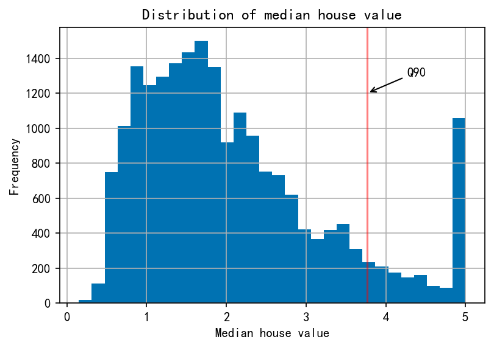

```python
house_value.hist(bins=30)

plt.axvline(x=house_value.quantile(0.9), c='r', alpha=0.5)
plt.annotate(s='Q90',xy=(house_value.quantile(0.9),1200),
            xytext=(house_value.quantile(0.9)+0.5,1300),
            arrowprops={'arrowstyle':'->'})
plt.title('Distribution of median house value')
plt.ylabel('Frequency')
plt.xlabel('Median house value')
```

```python
features = list(housing.columns)
q90 = house_value.quantile(0.9)
X_all, y_all = housing[features], house_value.map(lambda x: 1 if x>q90 else 0)
```

```python
# with open('data_ch.pkl','wb') as f:
#     pickle.dump([X_all,y_all],f,4)
# with open('data_ch.pkl','rb') as f:
#     X_all,y_all = pickle.load(f)
features = list(X_all.columns)
```

```python
print(X_all.shape)
print(y_all.shape)
y_all.value_counts(normalize=True)
```

```
(20640, 8)
(20640,)
```

```
0    0.900048
1    0.099952
Name: MedHouseVal, dtype: float64
```

```python
from sklearn.model_selection import train_test_split
X, X_val, y, y_val = train_test_split(X_all, y_all, test_size=0.4, stratify=y_all, random_state=42)
print(X.shape)
print(y.shape)
print(X_val.shape)
print(y_val.shape)
```

```
(12384, 8)
(12384,)
(8256, 8)
(8256,)
```

```python
y.value_counts(normalize=True)
```

```
0    0.900032
1    0.099968
Name: MedHouseVal, dtype: float64
```

```python
y_val.value_counts(normalize=True)
```

```
0    0.900073
1    0.099927
Name: MedHouseVal, dtype: float64
```

## Scorecard Model

```python
from scorecardbundle.feature_discretization import ChiMerge as cm
from scorecardbundle.feature_discretization import FeatureIntervalAdjustment as fia
from scorecardbundle.feature_encoding import WOE as woe
from scorecardbundle.feature_selection import FeatureSelection as fs
from scorecardbundle.model_training import LogisticRegressionScoreCard as lrsc
from scorecardbundle.model_evaluation import ModelEvaluation as me
from scorecardbundle.model_interpretation import ScorecardExplainer as mise

# from temp.feature_discretization import ChiMerge as cm
# from temp.feature_discretization import FeatureIntervalAdjustment as fia
# from temp.feature_encoding import WOE as woe
# from temp.feature_selection import FeatureSelection as fs
# from temp.model_training import LogisticRegressionScoreCard as lrsc
# from temp.model_evaluation import ModelEvaluation as me
# from temp.model_interpretation import ScorecardExplainer as mise

# from importlib import reload
# reload(cm)
# reload(fia)
# reload(woe)
# reload(fs)
# reload(lrsc)
# reload(me)
# reload(mise)
```

```python
from sklearn.feature_selection import chi2
from sklearn.preprocessing import MinMaxScaler
from sklearn.preprocessing import OrdinalEncoder
from sklearn.utils import class_weight
from sklearn.linear_model import LogisticRegression
from sklearn.model_selection import GridSearchCV
```

### Feature selection before feature discretization

#### Predictability

Evaluate the predictive power of features with information value (IV) and Chi2-test

```python
# IV
trans_woe_raw = woe.WOE_Encoder(output_dataframe=True)
result_woe_raw = trans_woe_raw.fit_transform(X,y)
```

```python
# Chi2
res_chi2 = chi2(MinMaxScaler().fit_transform(X),y)
```

```python
# IV result
res_iv = pd.DataFrame.from_dict(trans_woe_raw.iv_, orient='index').sort_values(0,ascending=False).reset_index()
res_iv.columns = ['feature','IV']
# Chi2 result
res_chi2 = pd.DataFrame(np.stack(res_chi2,axis=1),columns=['Chi2_stat','Chi2_pvalue'])
res_chi2['feature'] = X.columns
# Merge
res_predictability = res_iv.merge(res_chi2,on='feature')
res_predictability.sort_values('Chi2_stat',ascending=False)
```

|  | feature | IV | Chi2_stat | Chi2_pvalue |
| --- | --- | --- | --- | --- |
| 2 | MedInc | 41.907477 | 233.757316 | 9.035722e-53 |
| 7 | HouseAge | 0.236777 | 14.327894 | 1.535724e-04 |
| 6 | Latitude | 8.314223 | 3.827785 | 5.040950e-02 |
| 1 | AveOccup | 45.534320 | 2.614352 | 1.059008e-01 |
| 0 | AveRooms | 47.130083 | 2.489447 | 1.146120e-01 |
| 5 | Longitude | 8.396207 | 1.395161 | 2.375354e-01 |
| 4 | Population | 16.181549 | 1.337689 | 2.474419e-01 |
| 3 | AveBedrms | 37.630560 | 0.000038 | 9.950798e-01 |

```python
mask_iv = res_predictability.IV>0.02
mask_chi2 = res_predictability.Chi2_pvalue<=0.05
print(f'There are {X.shape[1]} features in total. {sum(mask_iv)} features have IV that is larger than 0.02, while only {sum(mask_chi2)} features passed the Chi2 test')
```

```
There are 8 features in total. 8 features have IV that is larger than 0.02, while only 2 features passed the Chi2 test
```

In this case, no feature is dropped since all their IVs are larger than 0.02.

#### Colinearity

Identify highly-correlated feature pairs where the feature with lower IV is dropped.

In this example, a pair of features are highly-correlated if their Pearson Correlation Coefficient is larger than 0.7

```python
fs.selection_with_iv_corr(trans_woe_raw, result_woe_raw,threshold_corr=0.7)
```

|  | factor | IV | woe_dict | corr_with |
| --- | --- | --- | --- | --- |
| 2 | AveRooms | 47.130083 | {0.8461538461538461: -23.025850929940457, 1.0:... | {'MedInc': 0.886954762287924, 'AveBedrms': 0.8... |
| 5 | AveOccup | 45.534320 | {1.0892678034102308: -23.025850929940457, 1.08... | {'MedInc': 0.8654189306421639, 'AveRooms': 0.9... |
| 0 | MedInc | 41.907477 | {0.4999: -23.025850929940457, 0.536: -23.02585... | {'AveRooms': 0.886954762287924, 'AveBedrms': 0... |
| 3 | AveBedrms | 37.630560 | {0.4444444444444444: -23.025850929940457, 0.5:... | {'MedInc': 0.7527641328927565, 'AveRooms': 0.8... |
| 4 | Population | 16.181549 | {5.0: -23.025850929940457, 6.0: -23.0258509299... | {} |
| 7 | Longitude | 8.396207 | {-124.35: -23.025850929940457, -124.27: -23.02... | {} |
| 6 | Latitude | 8.314223 | {32.54: -23.025850929940457, 32.55: -23.025850... | {} |
| 1 | HouseAge | 0.236777 | {1.0: -23.025850929940457, 2.0: 0.341285523686... | {} |

```python
features_to_drop_auto,features_to_drop_manual,corr_auto,corr_manual = fs.identify_colinear_features(result_woe_raw,trans_woe_raw.iv_,threshold_corr=0.7)
print('The features with lower IVs in highly correlated pairs: ',features_to_drop_auto)
print('The features with equal IVs in highly correlated pairs: ',features_to_drop_manual)
```

```
The features with lower IVs in highly correlated pairs:  ['MedInc', 'AveBedrms', 'AveOccup']
The features with equal IVs in highly correlated pairs:  []
```

```python
corr_auto # highly correlated features (with unequal IVs)
```

|  | feature_a | feature_b | corr_coef | iv_feature_a | iv_feature_b | to_drop |
| --- | --- | --- | --- | --- | --- | --- |
| 0 | MedInc | AveRooms | 0.886955 | 41.907477 | 47.130083 | MedInc |
| 1 | MedInc | AveBedrms | 0.752764 | 41.907477 | 37.630560 | AveBedrms |
| 2 | MedInc | AveOccup | 0.865419 | 41.907477 | 45.534320 | MedInc |
| 3 | AveRooms | MedInc | 0.886955 | 47.130083 | 41.907477 | MedInc |
| 4 | AveRooms | AveBedrms | 0.827336 | 47.130083 | 37.630560 | AveBedrms |
| 5 | AveRooms | AveOccup | 0.952849 | 47.130083 | 45.534320 | AveOccup |
| 6 | AveBedrms | MedInc | 0.752764 | 37.630560 | 41.907477 | AveBedrms |
| 7 | AveBedrms | AveRooms | 0.827336 | 37.630560 | 47.130083 | AveBedrms |
| 8 | AveBedrms | AveOccup | 0.811198 | 37.630560 | 45.534320 | AveBedrms |
| 9 | AveOccup | MedInc | 0.865419 | 45.534320 | 41.907477 | MedInc |
| 10 | AveOccup | AveRooms | 0.952849 | 45.534320 | 47.130083 | AveOccup |
| 11 | AveOccup | AveBedrms | 0.811198 | 45.534320 | 37.630560 | AveBedrms |

```python
corr_manual # highly correlated features (with equal IVs)
```

|  | feature_a | feature_b | corr_coef | iv_feature_a | iv_feature_b | to_drop |
| --- | --- | --- | --- | --- | --- | --- |

Based on the analysis results above, 'MedInc', 'AveBedrms', and 'AveOccup' are dropped.

```python
feature_list = list(set(features)-set(['MedInc', 'AveBedrms', 'AveOccup']))
print(feature_list)
```

```
['HouseAge', 'Population', 'AveRooms', 'Latitude', 'Longitude']
```

### Feature Discretization

```python
trans_cm = cm.ChiMerge(max_intervals=10, min_intervals=2, decimal=3, output_dataframe=True) # Given the meanings of these features, round them up to 3 decimals
result_cm = trans_cm.fit_transform(X[feature_list], y)
result_cm.head()
```

|  | HouseAge | Population | AveRooms | Latitude | Longitude |
| --- | --- | --- | --- | --- | --- |
| 0 | 36.0~45.0 | 877.0~1274.0 | 4.975~5.962 | 33.63~34.1 | -118.37~-117.82 |
| 1 | 17.0~24.0 | 1274.0~2812.0 | 4.975~5.962 | 33.63~34.1 | -117.77~-117.14 |
| 2 | 36.0~45.0 | 1274.0~2812.0 | -inf~4.944 | 33.63~34.1 | -118.37~-117.82 |
| 3 | 25.0~36.0 | 877.0~1274.0 | 6.426~6.95 | 37.99~inf | -inf~-122.6 |
| 4 | 36.0~45.0 | 1274.0~2812.0 | -inf~4.944 | 33.63~34.1 | -118.37~-117.82 |

```python
trans_cm.boundaries_ # show boundaries for all features
```

```
{'HouseAge': array([ 9., 17., 24., 25., 36., 45., 47., 51., inf]),
 'Population': array([ 351.,  420.,  455.,  679.,  694.,  877., 1274., 2812.,   inf]),
 'AveRooms': array([ 4.944,  4.975,  5.962,  6.265,  6.426,  6.95 ,  7.461,  8.211,
        10.116,    inf]),
 'Latitude': array([33.246, 33.63 , 34.1  , 34.16 , 34.47 , 37.12 , 37.59 , 37.75 ,
        37.99 ,    inf]),
 'Longitude': array([-122.6 , -122.37, -121.59, -119.85, -118.7 , -118.37, -117.82,
        -117.77, -117.14,     inf])}
```

```python
feature_doc = pd.DataFrame({
    'feature':feature_list
})
feature_doc['num_intervals'] = feature_doc['feature'].map(result_cm.nunique().to_dict())
feature_doc['min_interval_size'] = [fia.feature_stat(result_cm[col].values,y.values)['sample_size'].min() for col in feature_doc['feature']]
feature_doc
```

|  | feature | num_intervals | min_interval_size |
| --- | --- | --- | --- |
| 0 | AveRooms | 10 | 123 |
| 1 | Population | 9 | 121 |
| 2 | Latitude | 10 | 266 |
| 3 | HouseAge | 9 | 270 |
| 4 | Longitude | 10 | 113 |

### Feature selection after feature discretization

#### Predictability

```python
# IV
trans_woe_tem = woe.WOE_Encoder(output_dataframe=True)
result_woe_tem = trans_woe_tem.fit_transform(result_cm,y) # 0:05:54.309297
# Chi2
res_chi2_tem = chi2(OrdinalEncoder().fit_transform(result_cm),y)

# IV result
res_iv_af = pd.DataFrame.from_dict(trans_woe_tem.iv_, orient='index').sort_values(0,ascending=False).reset_index()
res_iv_af.columns = ['feature','IV']
# Chi2 result
res_chi2_af = pd.DataFrame(np.stack(res_chi2_tem,axis=1),columns=['Chi2_stat','Chi2_pvalue'])
res_chi2_af['feature'] = feature_list
# Merge
res_predictability_af = res_iv_af.merge(res_chi2_af,on='feature')
res_predictability_af.sort_values('Chi2_stat',ascending=False)
```

|  | feature | IV | Chi2_stat | Chi2_pvalue |
| --- | --- | --- | --- | --- |
| 2 | AveRooms | 0.857210 | 2446.716364 | 0.000000e+00 |
| 4 | Population | 0.083081 | 78.704616 | 7.212685e-19 |
| 0 | Longitude | 1.128062 | 61.468825 | 4.498091e-15 |
| 1 | Latitude | 0.918885 | 40.402233 | 2.067048e-10 |
| 3 | HouseAge | 0.207515 | 0.405814 | 5.241018e-01 |

```python
mask_iv = res_predictability_af.IV>0.02
mask_chi2 = res_predictability_af.Chi2_pvalue<=0.05
print(f'There are {len(feature_list)} features in total. {sum(mask_iv)} features have IV that is larger than 0.02, while {sum(mask_chi2)} features passed the Chi2 test')
```

```
There are 5 features in total. 5 features have IV that is larger than 0.02, while 4 features passed the Chi2 test
```

Thus no feature is dropped

#### Colinearity

```python
fs.selection_with_iv_corr(trans_woe_tem, result_woe_tem,threshold_corr=0.7)
```

|  | factor | IV | woe_dict | corr_with |
| --- | --- | --- | --- | --- |
| 4 | Longitude | 1.128062 | {'-117.14~inf': -2.2462435206496125, '-117.77~... | {} |
| 3 | Latitude | 0.918885 | {'-inf~33.246': -0.4425554813458228, '33.246~3... | {} |
| 2 | AveRooms | 0.857210 | {'-inf~4.944': -0.7019702781704262, '10.116~in... | {} |
| 0 | HouseAge | 0.207515 | {'-inf~9.0': -0.09950705958146305, '17.0~24.0'... | {} |
| 1 | Population | 0.083081 | {'-inf~351.0': 0.0321076350596391, '1274.0~281... | {} |

```python
# Have a look at the correlation table
fs.unstacked_corr_table(result_woe_tem,trans_woe_tem.iv_)
```

|  | feature_a | feature_b | corr_coef | abs_corr_coef | iv_feature_a | iv_feature_b |
| --- | --- | --- | --- | --- | --- | --- |
| 19 | Longitude | Latitude | 0.422641 | 0.422641 | 1.128062 | 0.918885 |
| 15 | Latitude | Longitude | 0.422641 | 0.422641 | 0.918885 | 1.128062 |
| 16 | Longitude | HouseAge | 0.207760 | 0.207760 | 1.128062 | 0.207515 |
| 3 | HouseAge | Longitude | 0.207760 | 0.207760 | 0.207515 | 1.128062 |
| 0 | HouseAge | Population | 0.173051 | 0.173051 | 0.207515 | 0.083081 |
| 4 | Population | HouseAge | 0.173051 | 0.173051 | 0.083081 | 0.207515 |
| 12 | Latitude | HouseAge | 0.146052 | 0.146052 | 0.918885 | 0.207515 |
| 2 | HouseAge | Latitude | 0.146052 | 0.146052 | 0.207515 | 0.918885 |
| 8 | AveRooms | HouseAge | -0.100326 | 0.100326 | 0.857210 | 0.207515 |
| 1 | HouseAge | AveRooms | -0.100326 | 0.100326 | 0.207515 | 0.857210 |
| 6 | Population | Latitude | -0.045584 | 0.045584 | 0.083081 | 0.918885 |
| 13 | Latitude | Population | -0.045584 | 0.045584 | 0.918885 | 0.083081 |
| 5 | Population | AveRooms | 0.042085 | 0.042085 | 0.083081 | 0.857210 |
| 9 | AveRooms | Population | 0.042085 | 0.042085 | 0.857210 | 0.083081 |
| 7 | Population | Longitude | -0.030407 | 0.030407 | 0.083081 | 1.128062 |
| 17 | Longitude | Population | -0.030407 | 0.030407 | 1.128062 | 0.083081 |
| 14 | Latitude | AveRooms | 0.026915 | 0.026915 | 0.918885 | 0.857210 |
| 10 | AveRooms | Latitude | 0.026915 | 0.026915 | 0.857210 | 0.918885 |
| 11 | AveRooms | Longitude | -0.007423 | 0.007423 | 0.857210 | 1.128062 |
| 18 | Longitude | AveRooms | -0.007423 | 0.007423 | 1.128062 | 0.857210 |

In case of automatically discretized values, there are no highly-correlated features.

### Feature Engineering (manually adjusting feature intervals)

Analyze the sample distribution and event rate distribution for each feature, and adjust the feature intervals so that the feature's predictability is intuitive to humen (high expalinability). Of course the feature need to maintain a reasonable predicbility (e.g. has a IV larger than 0.02)

```python
feature_selected = []
```

```python
feature_list
```

```
['HouseAge', 'Population', 'AveRooms', 'Latitude', 'Longitude']
```

#### Latitude

```python
col = 'Latitude'
```

```
feature             sample_size         event_num           event_pct
(right-closed)
- - - - - - - - - - - - - - - - - - - - - - - - - - - - - - - - - - - - - - - -
-inf~33.246         991                 66                  6.66%
- - - - - - - - - - - - - - - - - - - - - - - - - - - - - - - - - - - - - - - -
33.246~33.63        266                 79                  29.7%
- - - - - - - - - - - - - - - - - - - - - - - - - - - - - - - - - - - - - - - -
33.63~34.1          3807                369                 9.69%
- - - - - - - - - - - - - - - - - - - - - - - - - - - - - - - - - - - - - - - -
34.1~34.16          551                 139                 25.23%
- - - - - - - - - - - - - - - - - - - - - - - - - - - - - - - - - - - - - - - -
34.16~34.47         949                 96                  10.12%
- - - - - - - - - - - - - - - - - - - - - - - - - - - - - - - - - - - - - - - -
34.47~37.12         1368                27                  1.97%
- - - - - - - - - - - - - - - - - - - - - - - - - - - - - - - - - - - - - - - -
37.12~37.59         997                 231                 23.17%
- - - - - - - - - - - - - - - - - - - - - - - - - - - - - - - - - - - - - - - -
37.59~37.75         631                 33                  5.23%
- - - - - - - - - - - - - - - - - - - - - - - - - - - - - - - - - - - - - - - -
37.75~37.99         1004                184                 18.33%
- - - - - - - - - - - - - - - - - - - - - - - - - - - - - - - - - - - - - - - -
37.99~inf           1820                14                  0.77%
- - - - - - - - - - - - - - - - - - - - - - - - - - - - - - - - - - - - - - - -
```

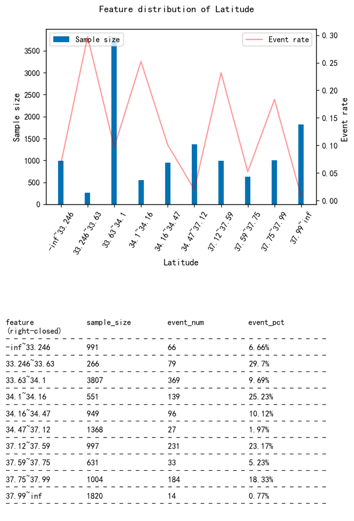

```python
fia.plot_event_dist(result_cm[col],y
                    ,title=f'Feature distribution of {col}'
                    ,x_label=col
                    ,y_label=''
                    ,x_rotation=60
                   ,save=False
                   ,file_name=col)
```

```python
new_x = cm.assign_interval_str(X[col].values,[34.1,34.47,37.59]) # pass new interval boundaries
woe.woe_vector(new_x, y.values)
```

```
({'-inf~34.1': 0.016924267593086018,
  '34.1~34.47': 0.5143416270268658,
  '34.47~37.59': 0.09752268519270618,
  '37.59~inf': -0.43837687896512034},
 0.08626935922214038)
```

```
feature             sample_size         event_num           event_pct
(right-closed)
- - - - - - - - - - - - - - - - - - - - - - - - - - - - - - - - - - - - - - - -
-inf~34.1           5064                514                 10.15%
- - - - - - - - - - - - - - - - - - - - - - - - - - - - - - - - - - - - - - - -
34.1~34.47          1500                235                 15.67%
- - - - - - - - - - - - - - - - - - - - - - - - - - - - - - - - - - - - - - - -
34.47~37.59         2365                258                 10.91%
- - - - - - - - - - - - - - - - - - - - - - - - - - - - - - - - - - - - - - - -
37.59~inf           3455                231                 6.69%
- - - - - - - - - - - - - - - - - - - - - - - - - - - - - - - - - - - - - - - -
```

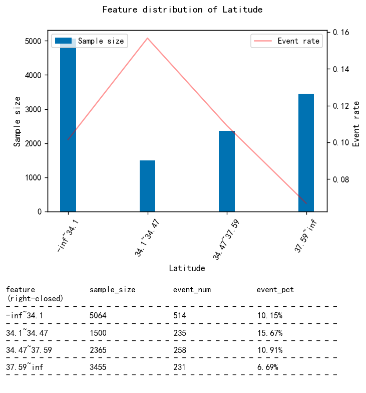

```python
fia.plot_event_dist(new_x,y
                    ,title=f'Feature distribution of {col}'
                    ,x_label=col
                    ,y_label=''
                    ,x_rotation=60
                   ,save=False
                   ,file_name=col
                   ,table_vpos=-0.6
                   )
```

```python
result_cm['Latitude'] = new_x # reasonable explainability and predictability. Select.
feature_selected.append('Latitude')
print(feature_selected)
```

```
['Latitude']
```

#### HouseAge

```python
col = 'HouseAge'
```

```
feature             sample_size         event_num           event_pct
(right-closed)
- - - - - - - - - - - - - - - - - - - - - - - - - - - - - - - - - - - - - - - -
-inf~9.0            799                 73                  9.14%
- - - - - - - - - - - - - - - - - - - - - - - - - - - - - - - - - - - - - - - -
9.0~17.0            2031                100                 4.92%
- - - - - - - - - - - - - - - - - - - - - - - - - - - - - - - - - - - - - - - -
17.0~24.0           2014                170                 8.44%
- - - - - - - - - - - - - - - - - - - - - - - - - - - - - - - - - - - - - - - -
24.0~25.0           344                 50                  14.53%
- - - - - - - - - - - - - - - - - - - - - - - - - - - - - - - - - - - - - - - -
25.0~36.0           3920                376                 9.59%
- - - - - - - - - - - - - - - - - - - - - - - - - - - - - - - - - - - - - - - -
36.0~45.0           1937                224                 11.56%
- - - - - - - - - - - - - - - - - - - - - - - - - - - - - - - - - - - - - - - -
45.0~47.0           270                 17                  6.3%
- - - - - - - - - - - - - - - - - - - - - - - - - - - - - - - - - - - - - - - -
47.0~51.0           310                 37                  11.94%
- - - - - - - - - - - - - - - - - - - - - - - - - - - - - - - - - - - - - - - -
51.0~inf            759                 191                 25.16%
- - - - - - - - - - - - - - - - - - - - - - - - - - - - - - - - - - - - - - - -
```

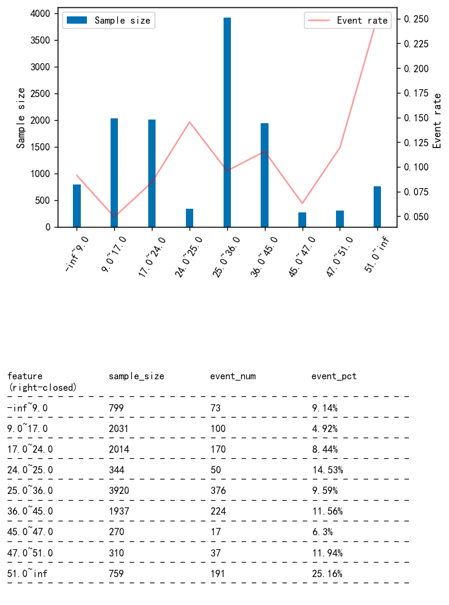

```python
fia.plot_event_dist(result_cm[col],y,x_rotation=60)
```

```python
new_x = cm.assign_interval_str(X[col].values,[24,36,45]) # pass new interval boundaries
woe.woe_vector(new_x, y.values)
```

```
({'-inf~24.0': -0.37674091199664517,
  '24.0~36.0': -0.0006838162136153891,
  '36.0~45.0': 0.16322806760041855,
  '45.0~inf': 0.7012457415969229},
 0.12215245735367213)
```

```
feature             sample_size         event_num           event_pct
(right-closed)
- - - - - - - - - - - - - - - - - - - - - - - - - - - - - - - - - - - - - - - -
-inf~24.0           4844                343                 7.08%
- - - - - - - - - - - - - - - - - - - - - - - - - - - - - - - - - - - - - - - -
24.0~36.0           4264                426                 9.99%
- - - - - - - - - - - - - - - - - - - - - - - - - - - - - - - - - - - - - - - -
36.0~45.0           1937                224                 11.56%
- - - - - - - - - - - - - - - - - - - - - - - - - - - - - - - - - - - - - - - -
45.0~inf            1339                245                 18.3%
- - - - - - - - - - - - - - - - - - - - - - - - - - - - - - - - - - - - - - - -
```

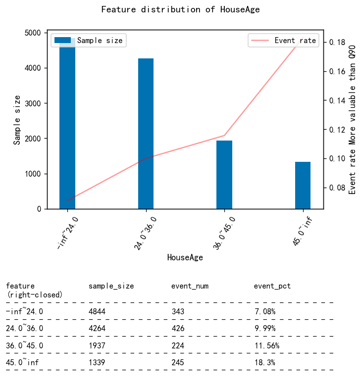

```python
fia.plot_event_dist(new_x,y
                    ,title=f'Feature distribution of {col}'
                    ,x_label=col
                    ,y_label='More valuable than Q90'
                    ,x_rotation=60
                   ,save=False
                   ,file_name=col
                   ,table_vpos=-0.6)
```

```python
result_cm[col] = new_x # great explainability and predictability. Select.
feature_selected.append(col)
print(feature_selected)
```

```
['Latitude', 'HouseAge']
```

#### Population

```python
col = 'Population'
```

```
feature             sample_size         event_num           event_pct
(right-closed)
- - - - - - - - - - - - - - - - - - - - - - - - - - - - - - - - - - - - - - - -
-inf~351.0          622                 64                  10.29%
- - - - - - - - - - - - - - - - - - - - - - - - - - - - - - - - - - - - - - - -
351.0~420.0         247                 37                  14.98%
- - - - - - - - - - - - - - - - - - - - - - - - - - - - - - - - - - - - - - - -
420.0~455.0         125                 10                  8.0%
- - - - - - - - - - - - - - - - - - - - - - - - - - - - - - - - - - - - - - - -
455.0~679.0         1240                172                 13.87%
- - - - - - - - - - - - - - - - - - - - - - - - - - - - - - - - - - - - - - - -
679.0~694.0         121                 8                   6.61%
- - - - - - - - - - - - - - - - - - - - - - - - - - - - - - - - - - - - - - - -
694.0~877.0         1493                204                 13.66%
- - - - - - - - - - - - - - - - - - - - - - - - - - - - - - - - - - - - - - - -
877.0~1274.0        3088                326                 10.56%
- - - - - - - - - - - - - - - - - - - - - - - - - - - - - - - - - - - - - - - -
1274.0~2812.0       4458                361                 8.1%
- - - - - - - - - - - - - - - - - - - - - - - - - - - - - - - - - - - - - - - -
2812.0~inf          990                 56                  5.66%
- - - - - - - - - - - - - - - - - - - - - - - - - - - - - - - - - - - - - - - -
```

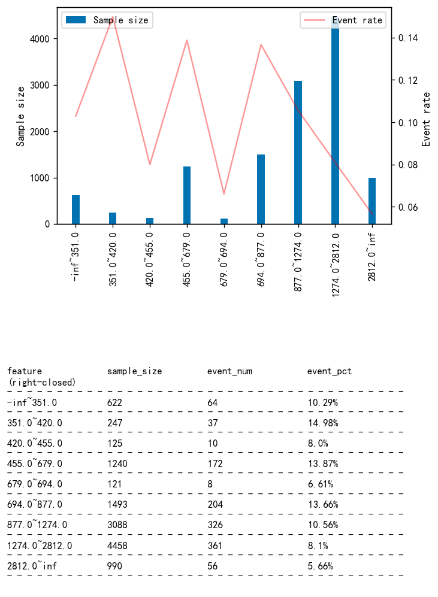

```python
fia.plot_event_dist(result_cm[col],y,x_rotation=90)
```

```python
new_x = cm.assign_interval_str(X[col].values,[420,694,877,1274,2812]) # pass new interval boundaries
woe.woe_vector(new_x, y.values)
```

```
({'-inf~420.0': 0.16891429776253228,
  '1274.0~2812.0': -0.2315488051033423,
  '2812.0~inf': -0.6165412333239324,
  '420.0~694.0': 0.2775697093085684,
  '694.0~877.0': 0.3540815049597504,
  '877.0~1274.0': 0.060770561476155},
 0.07217596403800937)
```

```
feature             sample_size         event_num           event_pct
(right-closed)
- - - - - - - - - - - - - - - - - - - - - - - - - - - - - - - - - - - - - - - -
-inf~420.0          869                 101                 11.62%
- - - - - - - - - - - - - - - - - - - - - - - - - - - - - - - - - - - - - - - -
420.0~694.0         1486                190                 12.79%
- - - - - - - - - - - - - - - - - - - - - - - - - - - - - - - - - - - - - - - -
694.0~877.0         1493                204                 13.66%
- - - - - - - - - - - - - - - - - - - - - - - - - - - - - - - - - - - - - - - -
877.0~1274.0        3088                326                 10.56%
- - - - - - - - - - - - - - - - - - - - - - - - - - - - - - - - - - - - - - - -
1274.0~2812.0       4458                361                 8.1%
- - - - - - - - - - - - - - - - - - - - - - - - - - - - - - - - - - - - - - - -
2812.0~inf          990                 56                  5.66%
- - - - - - - - - - - - - - - - - - - - - - - - - - - - - - - - - - - - - - - -
```

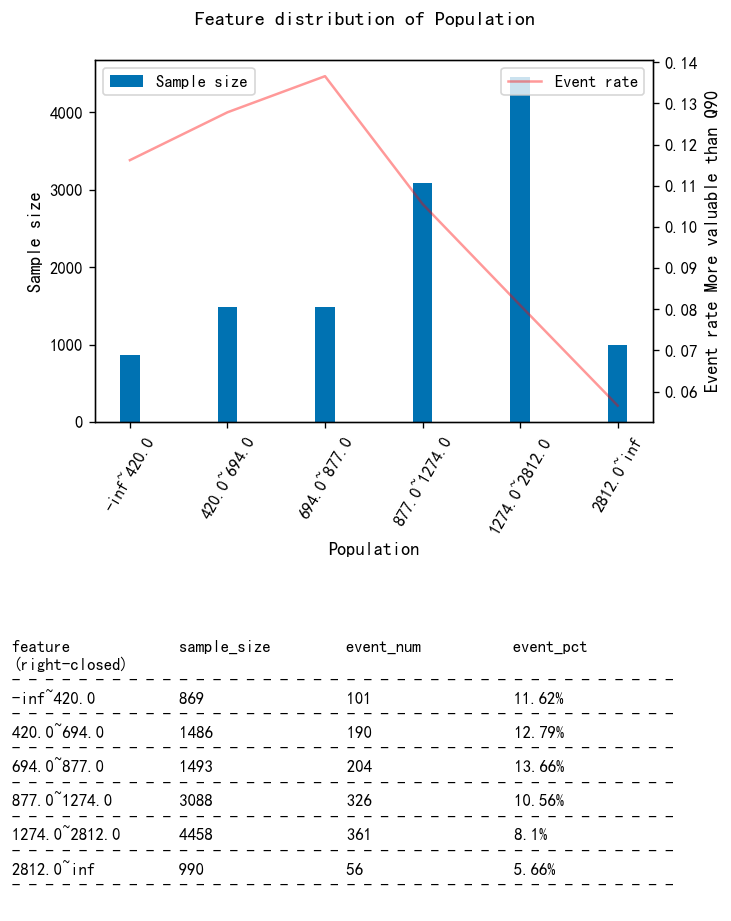

```python
fia.plot_event_dist(new_x,y
                    ,title=f'Feature distribution of {col}'
                    ,x_label=col
                    ,y_label='More valuable than Q90'
                    ,x_rotation=60
                   ,save=False
                   ,file_name=col)
```

```python
result_cm[col] = new_x # great explainability and predictability. Select.
feature_selected.append(col)
print(feature_selected)
```

```
['Latitude', 'HouseAge', 'Population']
```

#### Longitude

```python
col = 'Longitude'
```

```
feature             sample_size         event_num           event_pct
(right-closed)
- - - - - - - - - - - - - - - - - - - - - - - - - - - - - - - - - - - - - - - -
-inf~-122.6         375                 3                   0.8%
- - - - - - - - - - - - - - - - - - - - - - - - - - - - - - - - - - - - - - - -
-122.6~-122.37      621                 183                 29.47%
- - - - - - - - - - - - - - - - - - - - - - - - - - - - - - - - - - - - - - - -
-122.37~-121.59     2353                291                 12.37%
- - - - - - - - - - - - - - - - - - - - - - - - - - - - - - - - - - - - - - - -
-121.59~-119.85     1620                11                  0.68%
- - - - - - - - - - - - - - - - - - - - - - - - - - - - - - - - - - - - - - - -
-119.85~-118.7      978                 53                  5.42%
- - - - - - - - - - - - - - - - - - - - - - - - - - - - - - - - - - - - - - - -
-118.7~-118.37      912                 305                 33.44%
- - - - - - - - - - - - - - - - - - - - - - - - - - - - - - - - - - - - - - - -
-118.37~-117.82     3310                252                 7.61%
- - - - - - - - - - - - - - - - - - - - - - - - - - - - - - - - - - - - - - - -
-117.82~-117.77     113                 29                  25.66%
- - - - - - - - - - - - - - - - - - - - - - - - - - - - - - - - - - - - - - - -
-117.77~-117.14     1241                101                 8.14%
- - - - - - - - - - - - - - - - - - - - - - - - - - - - - - - - - - - - - - - -
-117.14~inf         861                 10                  1.16%
- - - - - - - - - - - - - - - - - - - - - - - - - - - - - - - - - - - - - - - -
```

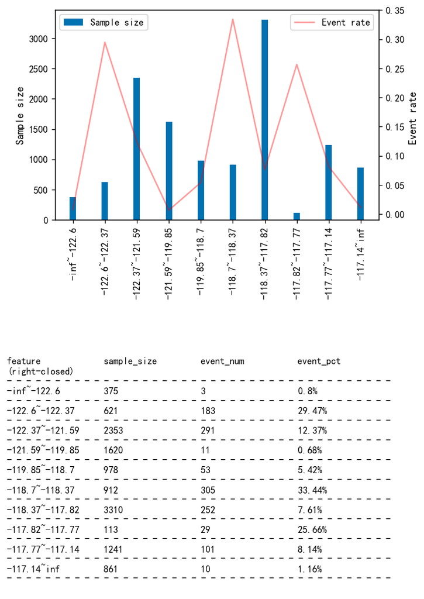

```python
fia.plot_event_dist(result_cm[col],y,x_rotation=90)
```

```python
new_x = cm.assign_interval_str(X[col].values,[-121.59,-118.37]) # pass new interval boundaries
woe.woe_vector(new_x, y.values)
```

```
({'-118.37~inf': -0.3746002086398019,
  '-121.59~-118.37': 0.05608365858101199,
  '-inf~-121.59': 0.4023360747716843},
 0.10616009747356592)
```

```
feature             sample_size         event_num           event_pct
(right-closed)
- - - - - - - - - - - - - - - - - - - - - - - - - - - - - - - - - - - - - - - -
-inf~-121.59        3349                477                 14.24%
- - - - - - - - - - - - - - - - - - - - - - - - - - - - - - - - - - - - - - - -
-121.59~-118.37     3510                369                 10.51%
- - - - - - - - - - - - - - - - - - - - - - - - - - - - - - - - - - - - - - - -
-118.37~inf         5525                392                 7.1%
- - - - - - - - - - - - - - - - - - - - - - - - - - - - - - - - - - - - - - - -
```

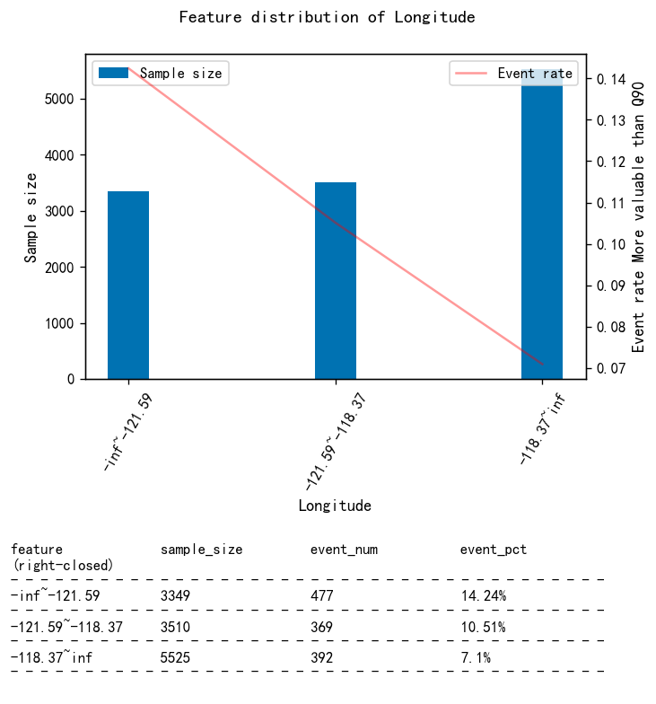

```python
fia.plot_event_dist(new_x,y
                    ,title=f'Feature distribution of {col}'
                    ,x_label=col
                    ,y_label='More valuable than Q90'
                    ,x_rotation=60
                   ,save=False
                   ,file_name=col
                   ,table_vpos=-0.6
                   )
```

```python
result_cm[col] = new_x
feature_selected.append(col)
print(feature_selected)
```

```
['Latitude', 'HouseAge', 'Population', 'Longitude']
```

#### AveRooms

```python
col = 'AveRooms'
```

```
feature             sample_size         event_num           event_pct
(right-closed)
- - - - - - - - - - - - - - - - - - - - - - - - - - - - - - - - - - - - - - - -
-inf~4.944          5079                265                 5.22%
- - - - - - - - - - - - - - - - - - - - - - - - - - - - - - - - - - - - - - - -
4.944~4.975         123                 1                   0.81%
- - - - - - - - - - - - - - - - - - - - - - - - - - - - - - - - - - - - - - - -
4.975~5.962         3837                226                 5.89%
- - - - - - - - - - - - - - - - - - - - - - - - - - - - - - - - - - - - - - - -
5.962~6.265         868                 86                  9.91%
- - - - - - - - - - - - - - - - - - - - - - - - - - - - - - - - - - - - - - - -
6.265~6.426         370                 51                  13.78%
- - - - - - - - - - - - - - - - - - - - - - - - - - - - - - - - - - - - - - - -
6.426~6.95          869                 162                 18.64%
- - - - - - - - - - - - - - - - - - - - - - - - - - - - - - - - - - - - - - - -
6.95~7.461          495                 140                 28.28%
- - - - - - - - - - - - - - - - - - - - - - - - - - - - - - - - - - - - - - - -
7.461~8.211         371                 159                 42.86%
- - - - - - - - - - - - - - - - - - - - - - - - - - - - - - - - - - - - - - - -
8.211~10.116        248                 134                 54.03%
- - - - - - - - - - - - - - - - - - - - - - - - - - - - - - - - - - - - - - - -
10.116~inf          124                 14                  11.29%
- - - - - - - - - - - - - - - - - - - - - - - - - - - - - - - - - - - - - - - -
```

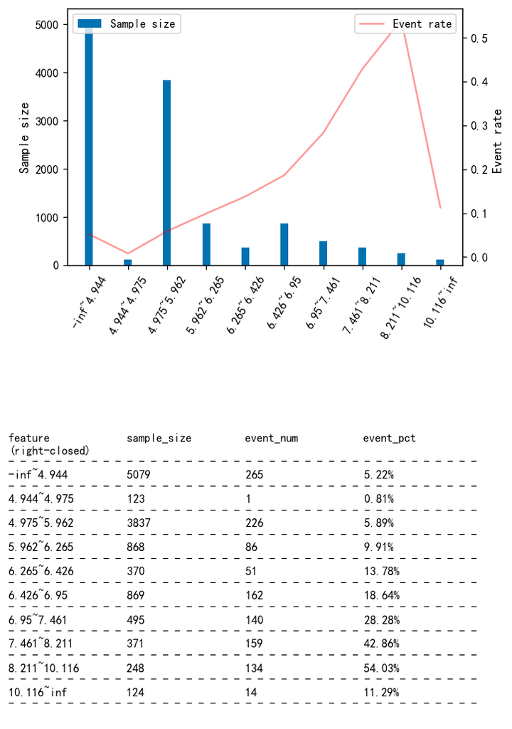

```python
fia.plot_event_dist(result_cm[col],y,x_rotation=60)
```

```python
new_x = cm.assign_interval_str(X[col].values,[5.96,6.426,6.95,7.41]) # pass new interval boundaries
woe.woe_vector(new_x, y.values)
```

```
({'-inf~5.96': -0.6604102786247698,
  '5.96~6.426': 0.12084345985346893,
  '6.426~6.95': 0.7241491833687606,
  '6.95~7.41': 1.2616398442370877,
  '7.41~inf': 1.828642336693169},
 0.7824038737089276)
```

```
feature             sample_size         event_num           event_pct
(right-closed)
- - - - - - - - - - - - - - - - - - - - - - - - - - - - - - - - - - - - - - - -
-inf~5.96           9029                490                 5.43%
- - - - - - - - - - - - - - - - - - - - - - - - - - - - - - - - - - - - - - - -
5.96~6.426          1248                139                 11.14%
- - - - - - - - - - - - - - - - - - - - - - - - - - - - - - - - - - - - - - - -
6.426~6.95          869                 162                 18.64%
- - - - - - - - - - - - - - - - - - - - - - - - - - - - - - - - - - - - - - - -
6.95~7.41           465                 131                 28.17%
- - - - - - - - - - - - - - - - - - - - - - - - - - - - - - - - - - - - - - - -
7.41~inf            773                 316                 40.88%
- - - - - - - - - - - - - - - - - - - - - - - - - - - - - - - - - - - - - - - -
```

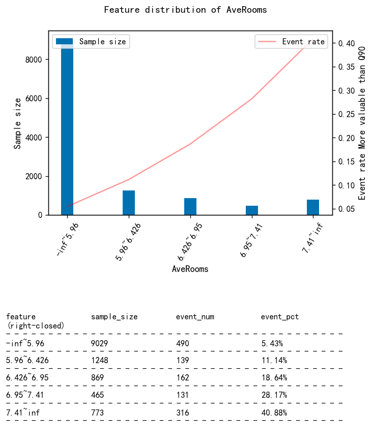

```python
fia.plot_event_dist(new_x,y
                    ,title=f'Feature distribution of {col}'
                    ,x_label=col
                    ,y_label='More valuable than Q90'
                    ,x_rotation=60
                   ,save=False
                   ,file_name=col)
```

```python
result_cm[col] = new_x # reasonable explainability and predictability. Select.
feature_selected.append(col)
print(feature_selected)
```

```
['Latitude', 'HouseAge', 'Population', 'Longitude', 'AveRooms']
```

### Feature Encoding with Weight of Evidence (WOE)

```python
print(feature_selected)
```

```
['Latitude', 'HouseAge', 'Population', 'Longitude', 'AveRooms']
```

```python
trans_woe = woe.WOE_Encoder(output_dataframe=True)
result_woe = trans_woe.fit_transform(result_cm[feature_selected], y) # WOE is fast. This only takes less then 1 seconds
result_woe.head()
```

|  | Latitude | HouseAge | Population | Longitude | AveRooms |
| --- | --- | --- | --- | --- | --- |
| 0 | 0.016924 | 0.163228 | 0.060771 | -0.374600 | -0.660410 |
| 1 | 0.016924 | -0.376741 | -0.231549 | -0.374600 | -0.660410 |
| 2 | 0.016924 | 0.163228 | -0.231549 | -0.374600 | -0.660410 |
| 3 | -0.438377 | -0.000684 | 0.060771 | 0.402336 | 0.724149 |
| 4 | 0.016924 | 0.163228 | -0.231549 | -0.374600 | -0.660410 |

```python
trans_woe.iv_ # the information value (iv) for each feature
```

```
{'Latitude': 0.08626935922214038,
 'HouseAge': 0.12215245735367213,
 'Population': 0.07217596403800937,
 'Longitude': 0.10616009747356592,
 'AveRooms': 0.7824038737089276}
```

### Double check predictability and colinearity

#### predictability

```python
# IV
trans_woe_tem = woe.WOE_Encoder(output_dataframe=True)
result_woe_tem = trans_woe_tem.fit_transform(result_cm[feature_list],y) # 0:05:54.309297
res_iv_selected = pd.DataFrame.from_dict(trans_woe_tem.iv_, orient='index').sort_values(0,ascending=False).reset_index()
res_iv_selected.columns = ['feature','IV']
res_iv_selected
```

|  | feature | IV |
| --- | --- | --- |
| 0 | AveRooms | 0.782404 |
| 1 | HouseAge | 0.122152 |
| 2 | Longitude | 0.106160 |
| 3 | Latitude | 0.086269 |
| 4 | Population | 0.072176 |

All features' IV are above 0.02

#### colinearity

```python
fs.selection_with_iv_corr(trans_woe, result_woe)
```

|  | factor | IV | woe_dict | corr_with |
| --- | --- | --- | --- | --- |
| 4 | AveRooms | 0.782404 | {'-inf~5.96': -0.6604102786247698, '5.96~6.426... | {} |
| 1 | HouseAge | 0.122152 | {'-inf~24.0': -0.37674091199664517, '24.0~36.0... | {} |
| 3 | Longitude | 0.106160 | {'-118.37~inf': -0.3746002086398019, '-121.59~... | {} |
| 0 | Latitude | 0.086269 | {'-inf~34.1': 0.016924267593086018, '34.1~34.4... | {} |
| 2 | Population | 0.072176 | {'-inf~420.0': 0.16891429776253228, '1274.0~28... | {} |

```python
fs.unstacked_corr_table(result_woe,trans_woe.iv_)
```

|  | feature_a | feature_b | corr_coef | abs_corr_coef | iv_feature_a | iv_feature_b |
| --- | --- | --- | --- | --- | --- | --- |
| 12 | Longitude | Latitude | -0.464314 | 0.464314 | 0.106160 | 0.086269 |
| 2 | Latitude | Longitude | -0.464314 | 0.464314 | 0.086269 | 0.106160 |
| 5 | HouseAge | Population | 0.258828 | 0.258828 | 0.122152 | 0.072176 |
| 9 | Population | HouseAge | 0.258828 | 0.258828 | 0.072176 | 0.122152 |
| 17 | AveRooms | HouseAge | -0.168398 | 0.168398 | 0.782404 | 0.122152 |
| 7 | HouseAge | AveRooms | -0.168398 | 0.168398 | 0.122152 | 0.782404 |
| 8 | Population | Latitude | -0.113200 | 0.113200 | 0.072176 | 0.086269 |
| 1 | Latitude | Population | -0.113200 | 0.113200 | 0.086269 | 0.072176 |
| 10 | Population | Longitude | 0.096437 | 0.096437 | 0.072176 | 0.106160 |
| 14 | Longitude | Population | 0.096437 | 0.096437 | 0.106160 | 0.072176 |
| 6 | HouseAge | Longitude | 0.084304 | 0.084304 | 0.122152 | 0.106160 |
| 13 | Longitude | HouseAge | 0.084304 | 0.084304 | 0.106160 | 0.122152 |
| 0 | Latitude | HouseAge | -0.083942 | 0.083942 | 0.086269 | 0.122152 |
| 4 | HouseAge | Latitude | -0.083942 | 0.083942 | 0.122152 | 0.086269 |
| 11 | Population | AveRooms | 0.061109 | 0.061109 | 0.072176 | 0.782404 |
| 18 | AveRooms | Population | 0.061109 | 0.061109 | 0.782404 | 0.072176 |
| 15 | Longitude | AveRooms | 0.043330 | 0.043330 | 0.106160 | 0.782404 |
| 19 | AveRooms | Longitude | 0.043330 | 0.043330 | 0.782404 | 0.106160 |
| 16 | AveRooms | Latitude | 0.016704 | 0.016704 | 0.782404 | 0.086269 |
| 3 | Latitude | AveRooms | 0.016704 | 0.016704 | 0.086269 | 0.782404 |

There are no highly-correlated features

```python
cmap = sns.light_palette("steelblue", as_cmap=True)
result_woe.corr().style.background_gradient(cmap=cmap)
```

|  | Latitude | HouseAge | Population | Longitude | AveRooms |
| --- | --- | --- | --- | --- | --- |
| Latitude | 1.000000 | -0.083942 | -0.113200 | -0.464314 | 0.016704 |
| HouseAge | -0.083942 | 1.000000 | 0.258828 | 0.084304 | -0.168398 |
| Population | -0.113200 | 0.258828 | 1.000000 | 0.096437 | 0.061109 |
| Longitude | -0.464314 | 0.084304 | 0.096437 | 1.000000 | 0.043330 |
| AveRooms | 0.016704 | -0.168398 | 0.061109 | 0.043330 | 1.000000 |

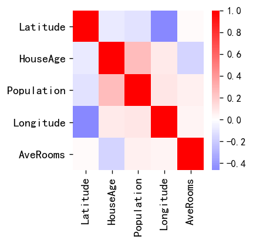

```python
corr_matrix = result_woe.corr()
plt.figure(figsize=(3,3))
sns.heatmap(corr_matrix, cmap = 'bwr', center=0)
plt.xticks(fontsize=12)
plt.yticks(fontsize=12)
plt.show()
```

### Model Training

```python
# Weight the positive class so that the model cares more about the classification performace of the positive class.
def compute_class_weight(labels):
    '''Compute weight for each class and return a dictionary.
    This is for the class_weight parameter in classifiers'''
    class_weights = class_weight.compute_class_weight('balanced', np.unique(labels), labels)
    return dict(zip(np.unique(labels), class_weights))

weights = compute_class_weight(y.values)
pos_weight = weights[1]/weights[0]
weights,pos_weight
```

```
({0: 0.5555356181589808, 1: 5.0016155088852985}, 9.003231017770597)
```

```python
# Search for the optimal parameters set for Logsitic regression
param_grid = {
 'C': np.arange(1,10)/10,
 'penalty':['l2','l1'],
'class_weight':[weights,None]
}

cl = LogisticRegression(max_iter=1000)
grid_search = GridSearchCV(cl, param_grid, cv=2, scoring='roc_auc',verbose=True,n_jobs=-1)
grid_search.fit(result_woe, y)

print('Best parameters:',grid_search.best_params_,
      '\n \n Best score',grid_search.best_score_,
      '\n \n Best model:',grid_search.best_estimator_
      )
```

```
[Parallel(n_jobs=-1)]: Using backend LokyBackend with 8 concurrent workers.
```

```
Fitting 2 folds for each of 36 candidates, totalling 72 fits
Best parameters: {'C': 0.6, 'class_weight': {0: 0.5555356181589808, 1: 5.0016155088852985}, 'penalty': 'l2'}

 Best score 0.80170744476238

 Best model: LogisticRegression(C=0.6,
                   class_weight={0: 0.5555356181589808, 1: 5.0016155088852985},
                   max_iter=1000)
```

```
[Parallel(n_jobs=-1)]: Done  34 tasks      | elapsed:    3.5s
[Parallel(n_jobs=-1)]: Done  72 out of  72 | elapsed:    3.6s finished
```

```python
model = lrsc.LogisticRegressionScoreCard(trans_woe, PDO=-20, basePoints=100, verbose=True,
                                        C=0.6, class_weight={0: 0.5555356181589808, 1: 5.0016155088852985},penalty='l2')
model.fit(result_woe, y)
```

```python
# # Users can use `baseOdds` parameter to set base odds.
# # Default is None, where base odds will be calculate using the number of positive class divided by the number of negative class in y
# # Assuming Users want base odds to be 1:60 (positive:negative)
# model = lrsc.LogisticRegressionScoreCard(trans_woe, PDO=-20, basePoints=100, baseOdds=1/60,
#                                          verbose=True,C=0.6, class_weight={0: 0.5555356181589808, 1: 5.0016155088852985},penalty='l2')
# model.fit(result_woe, y)
```

Access the Scorecard rule table by attribute `woe_df_`. This is the Scorecard model.

```python
model.woe_df_
```

|  | feature | value | woe | beta | score |
| --- | --- | --- | --- | --- | --- |
| 0 | Latitude | -inf~34.1 | 0.016924 | 1.907463 | 34.0 |
| 1 | Latitude | 34.1~34.47 | 0.514342 | 1.907463 | 61.0 |
| 2 | Latitude | 34.47~37.59 | 0.097523 | 1.907463 | 38.0 |
| 3 | Latitude | 37.59~inf | -0.438377 | 1.907463 | 9.0 |
| 4 | HouseAge | -inf~24.0 | -0.376741 | 1.640162 | 15.0 |
| 5 | HouseAge | 24.0~36.0 | -0.000684 | 1.640162 | 33.0 |
| 6 | HouseAge | 36.0~45.0 | 0.163228 | 1.640162 | 40.0 |
| 7 | HouseAge | 45.0~inf | 0.701246 | 1.640162 | 66.0 |
| 8 | Population | -inf~420.0 | 0.168914 | 0.464202 | 35.0 |
| 9 | Population | 1274.0~2812.0 | -0.231549 | 0.464202 | 30.0 |
| 10 | Population | 2812.0~inf | -0.616541 | 0.464202 | 24.0 |
| 11 | Population | 420.0~694.0 | 0.277570 | 0.464202 | 36.0 |
| 12 | Population | 694.0~877.0 | 0.354082 | 0.464202 | 37.0 |
| 13 | Population | 877.0~1274.0 | 0.060771 | 0.464202 | 34.0 |
| 14 | Longitude | -118.37~inf | -0.374600 | 1.643439 | 15.0 |
| 15 | Longitude | -121.59~-118.37 | 0.056084 | 1.643439 | 35.0 |
| 16 | Longitude | -inf~-121.59 | 0.402336 | 1.643439 | 52.0 |
| 17 | AveRooms | -inf~5.96 | -0.660410 | 1.124053 | 11.0 |
| 18 | AveRooms | 5.96~6.426 | 0.120843 | 1.124053 | 37.0 |
| 19 | AveRooms | 6.426~6.95 | 0.724149 | 1.124053 | 56.0 |
| 20 | AveRooms | 6.95~7.41 | 1.261640 | 1.124053 | 74.0 |
| 21 | AveRooms | 7.41~inf | 1.828642 | 1.124053 | 92.0 |

Scorecard should be applied on the **original feature values** (before discretization and WOE encoding).

Users can manually adjust the Scorecard rules (as shown below, or output excel files to local position, edit it in excel and load it), and use `load_scorecard` parameter of predict() to load the adjusted rule table. See details in the documentation of `load_scorecard`.

Assuming we want to change the highest score for `AveRooms` from 92 to 91.

```python
sc_table = model.woe_df_.copy()
sc_table['score'][(sc_table.feature=='AveRooms') & (sc_table.value=='7.41~inf')] = 91
sc_table
```

|  | feature | value | woe | beta | score |
| --- | --- | --- | --- | --- | --- |
| 0 | Latitude | -inf~34.1 | 0.016924 | 1.907463 | 34.0 |
| 1 | Latitude | 34.1~34.47 | 0.514342 | 1.907463 | 61.0 |
| 2 | Latitude | 34.47~37.59 | 0.097523 | 1.907463 | 38.0 |
| 3 | Latitude | 37.59~inf | -0.438377 | 1.907463 | 9.0 |
| 4 | HouseAge | -inf~24.0 | -0.376741 | 1.640162 | 15.0 |
| 5 | HouseAge | 24.0~36.0 | -0.000684 | 1.640162 | 33.0 |
| 6 | HouseAge | 36.0~45.0 | 0.163228 | 1.640162 | 40.0 |
| 7 | HouseAge | 45.0~inf | 0.701246 | 1.640162 | 66.0 |
| 8 | Population | -inf~420.0 | 0.168914 | 0.464202 | 35.0 |
| 9 | Population | 1274.0~2812.0 | -0.231549 | 0.464202 | 30.0 |
| 10 | Population | 2812.0~inf | -0.616541 | 0.464202 | 24.0 |
| 11 | Population | 420.0~694.0 | 0.277570 | 0.464202 | 36.0 |
| 12 | Population | 694.0~877.0 | 0.354082 | 0.464202 | 37.0 |
| 13 | Population | 877.0~1274.0 | 0.060771 | 0.464202 | 34.0 |
| 14 | Longitude | -118.37~inf | -0.374600 | 1.643439 | 15.0 |
| 15 | Longitude | -121.59~-118.37 | 0.056084 | 1.643439 | 35.0 |
| 16 | Longitude | -inf~-121.59 | 0.402336 | 1.643439 | 52.0 |
| 17 | AveRooms | -inf~5.96 | -0.660410 | 1.124053 | 11.0 |
| 18 | AveRooms | 5.96~6.426 | 0.120843 | 1.124053 | 37.0 |
| 19 | AveRooms | 6.426~6.95 | 0.724149 | 1.124053 | 56.0 |
| 20 | AveRooms | 6.95~7.41 | 1.261640 | 1.124053 | 74.0 |
| 21 | AveRooms | 7.41~inf | 1.828642 | 1.124053 | 91.0 |

```python
result = model.predict(X[feature_selected], load_scorecard=sc_table) # Scorecard should be applied on the original feature values
result_val = model.predict(X_val[feature_selected], load_scorecard=sc_table) # Scorecard should be applied on the original feature values
result.head() # if model object's verbose parameter is set to False, predict will only return Total scores
```

|  | Latitude | HouseAge | Population | Longitude | AveRooms | TotalScore |
| --- | --- | --- | --- | --- | --- | --- |
| 0 | 34.0 | 40.0 | 34.0 | 15.0 | 11.0 | 134.0 |
| 1 | 34.0 | 15.0 | 30.0 | 15.0 | 11.0 | 105.0 |
| 2 | 34.0 | 40.0 | 30.0 | 15.0 | 11.0 | 130.0 |
| 3 | 9.0 | 33.0 | 34.0 | 52.0 | 56.0 | 184.0 |
| 4 | 34.0 | 40.0 | 30.0 | 15.0 | 11.0 | 130.0 |

```python
# OR if we load rules from local position.

# sc_table = pd.read_excel('rules.xlsx')

# model = lrsc.LogisticRegressionScoreCard(woe_transformer=None, verbose=True)
# result = model.predict(X[feature_selected], load_scorecard=sc_table) # Scorecard should be applied on the original feature values
# result_val = model.predict(X_val[feature_selected], load_scorecard=sc_table) # Scorecard should be applied on the original feature values
```

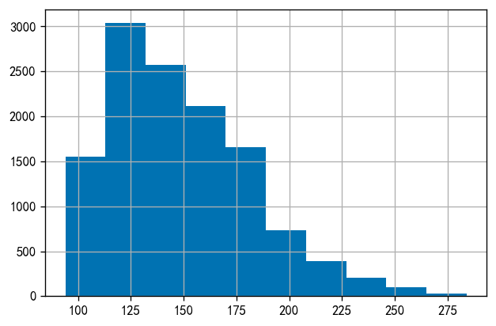

```python
result['TotalScore'].hist(bins=10)
```

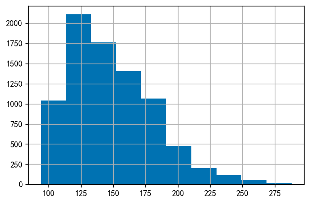

```python
result_val['TotalScore'].hist(bins=10)
```

### Model Evaluation

#### Train

##### Classification performance on differet levels of model scores

```python
me.pref_table(y,result['TotalScore'].values,thresholds=result['TotalScore'].quantile(np.arange(1,10)/10).values)
```

```
roc_auc_score=0.8033356721928685
AP=0.4071977253129474
```

|  | y_pred_group | event_num | sample_size | cum_event_num | cum_sample_size | cum_sample_pct | cum_precision | cum_recal | cum_f1 |
| --- | --- | --- | --- | --- | --- | --- | --- | --- | --- |
| 9 | (192.0, inf] | 503 | 1214 | 503 | 1214 | 0.098030 | 0.414333 | 0.406300 | 0.410277 |
| 8 | (174.0, 192.0] | 212 | 1179 | 715 | 2393 | 0.193233 | 0.298788 | 0.577544 | 0.393831 |
| 7 | (163.0, 174.0] | 163 | 1270 | 878 | 3663 | 0.295785 | 0.239694 | 0.709208 | 0.358294 |
| 6 | (152.0, 163.0] | 88 | 1269 | 966 | 4932 | 0.398256 | 0.195864 | 0.780291 | 0.313128 |
| 5 | (144.0, 152.0] | 91 | 1255 | 1057 | 6187 | 0.499596 | 0.170842 | 0.853796 | 0.284714 |
| 4 | (134.0, 144.0] | 76 | 1157 | 1133 | 7344 | 0.593023 | 0.154276 | 0.915186 | 0.264041 |
| 3 | (129.0, 134.0] | 25 | 1016 | 1158 | 8360 | 0.675065 | 0.138517 | 0.935380 | 0.241300 |
| 2 | (123.0, 129.0] | 38 | 1095 | 1196 | 9455 | 0.763485 | 0.126494 | 0.966074 | 0.223698 |
| 1 | (109.0, 123.0] | 25 | 1644 | 1221 | 11099 | 0.896237 | 0.110010 | 0.986268 | 0.197941 |
| 0 | (-inf, 109.0] | 17 | 1285 | 1238 | 12384 | 1.000000 | 0.099968 | 1.000000 | 0.181765 |

##### Performance plots

```python
evaluation = me.BinaryTargets(y, result['TotalScore'])
```

```python
evaluation.ks_stat()
```

```
0.4653488852756786
```

```
KS = 0.459
```

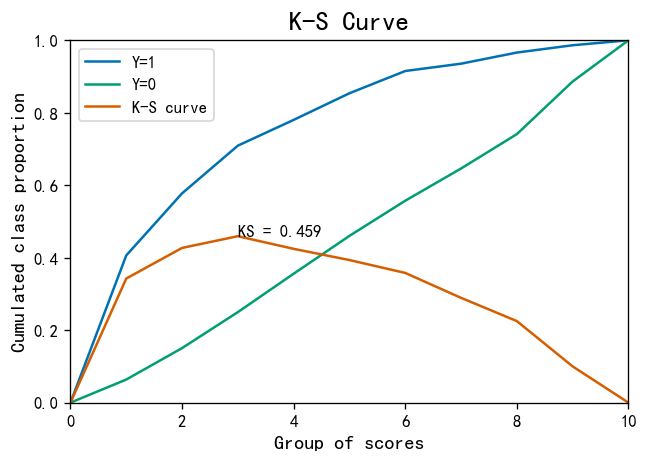

```python
evaluation.plot_ks()
```

```
AUC: 0.8033356721928685
```

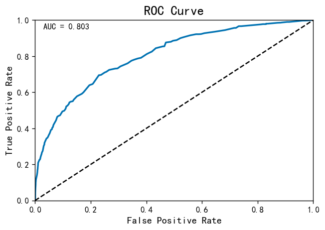

```python
evaluation.plot_roc()
```

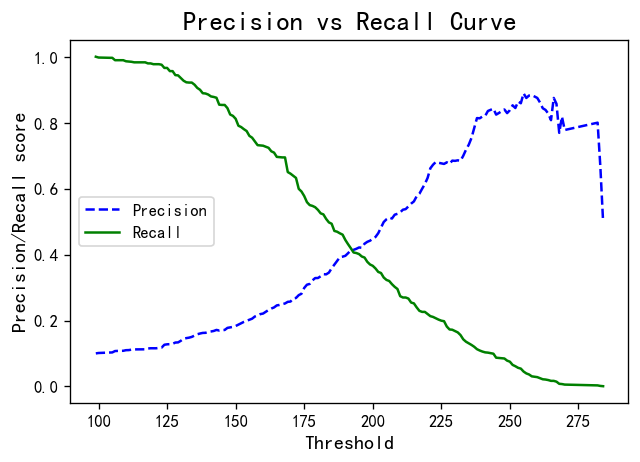

```python
evaluation.plot_precision_recall()
```

```
KS = 0.459
```

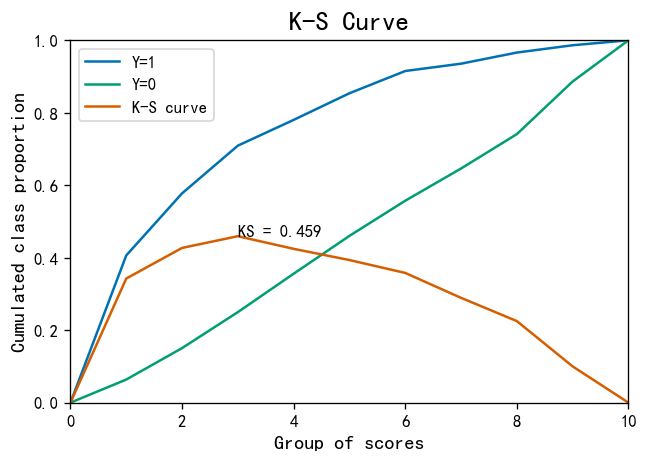

```
AUC: 0.8033356721928685
```

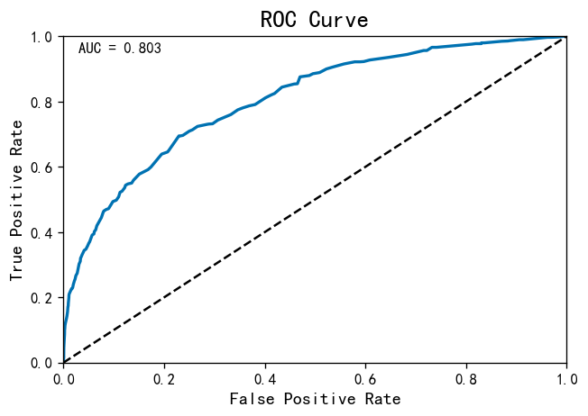

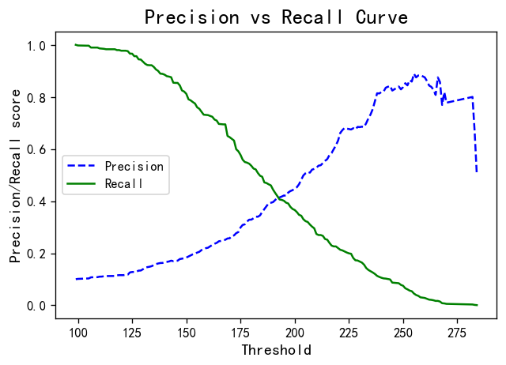

```python
evaluation.plot_all()
```

#### Validation

##### Classification performance on differet levels of model scores

```python
me.pref_table(y_val,result_val['TotalScore'].values,thresholds=result['TotalScore'].quantile(np.arange(1,10)/10).values)
```

```
roc_auc_score=0.8049962687023648
AP=0.4216926692604047
```

|  | y_pred_group | event_num | sample_size | cum_event_num | cum_sample_size | cum_sample_pct | cum_precision | cum_recal | cum_f1 |
| --- | --- | --- | --- | --- | --- | --- | --- | --- | --- |
| 9 | (192.0, inf] | 337 | 794 | 337 | 794 | 0.096172 | 0.424433 | 0.408485 | 0.416306 |
| 8 | (174.0, 192.0] | 143 | 794 | 480 | 1588 | 0.192345 | 0.302267 | 0.581818 | 0.397845 |
| 7 | (163.0, 174.0] | 96 | 891 | 576 | 2479 | 0.300266 | 0.232352 | 0.698182 | 0.348668 |
| 6 | (152.0, 163.0] | 79 | 862 | 655 | 3341 | 0.404675 | 0.196049 | 0.793939 | 0.314450 |
| 5 | (144.0, 152.0] | 53 | 793 | 708 | 4134 | 0.500727 | 0.171263 | 0.858182 | 0.285541 |
| 4 | (134.0, 144.0] | 42 | 740 | 750 | 4874 | 0.590359 | 0.153878 | 0.909091 | 0.263204 |
| 3 | (129.0, 134.0] | 24 | 709 | 774 | 5583 | 0.676235 | 0.138635 | 0.938182 | 0.241573 |
| 2 | (123.0, 129.0] | 25 | 762 | 799 | 6345 | 0.768532 | 0.125926 | 0.968485 | 0.222873 |
| 1 | (109.0, 123.0] | 18 | 1053 | 817 | 7398 | 0.896076 | 0.110435 | 0.990303 | 0.198711 |
| 0 | (-inf, 109.0] | 8 | 858 | 825 | 8256 | 1.000000 | 0.099927 | 1.000000 | 0.181698 |

##### Performance plots

```
KS = 0.448
```

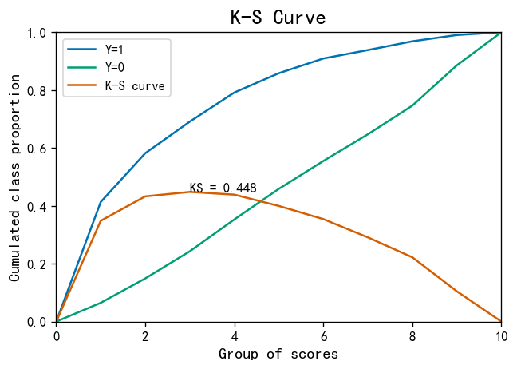

```
AUC: 0.8049962687023648
```

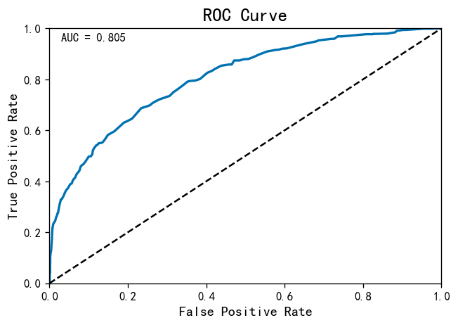

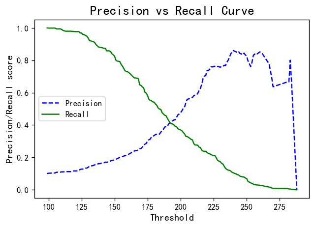

```python
evaluation = me.BinaryTargets(y_val, result_val['TotalScore'])
evaluation.plot_all()
```

### Model interpretation

Interprete the result for an instance by identifying the important features to the result

```python
list(sc_table.feature.unique())
```

```
['Latitude', 'HouseAge', 'Population', 'Longitude', 'AveRooms']
```

```python
# Features that contribute 80%+ of total score
imp_fs = mise.important_features(result_val
                   ,feature_names=list(sc_table.feature.unique())
                   ,col_totalscore='TotalScore'
                   ,threshold_method=0.8, bins=None)
result_val['important_features'] = imp_fs
```

```python
# Features with top n highest score
imp_fs = mise.important_features(result_val
                   ,feature_names=list(sc_table.feature.unique())
                   ,col_totalscore='TotalScore'
                   ,threshold_method=2, bins=None)
result_val['top2_features'] = imp_fs
```

```python
result_val
```

|  | Latitude | HouseAge | Population | Longitude | AveRooms | TotalScore | important_features | top2_features |
| --- | --- | --- | --- | --- | --- | --- | --- | --- |
| 0 | 38.0 | 15.0 | 30.0 | 35.0 | 11.0 | 129.0 | {'Latitude': 38.0, 'Longitude': 35.0, 'Populat... | {'Latitude': 38.0, 'Longitude': 35.0} |
| 1 | 9.0 | 15.0 | 30.0 | 35.0 | 11.0 | 100.0 | {'Longitude': 35.0, 'Population': 30.0} | {'Longitude': 35.0, 'Population': 30.0} |
| 2 | 9.0 | 15.0 | 34.0 | 52.0 | 11.0 | 121.0 | {'Longitude': 52.0, 'Population': 34.0} | {'Longitude': 52.0, 'Population': 34.0} |
| 3 | 9.0 | 66.0 | 36.0 | 52.0 | 11.0 | 174.0 | {'HouseAge': 66.0, 'Longitude': 52.0} | {'HouseAge': 66.0, 'Longitude': 52.0} |
| 4 | 34.0 | 15.0 | 37.0 | 15.0 | 91.0 | 192.0 | {'AveRooms': 91.0, 'Population': 37.0} | {'AveRooms': 91.0, 'Population': 37.0} |
| ... | ... | ... | ... | ... | ... | ... | ... | ... |
| 8251 | 34.0 | 33.0 | 37.0 | 15.0 | 37.0 | 156.0 | {'Population': 37.0, 'AveRooms': 37.0, 'Latitu... | {'Population': 37.0, 'AveRooms': 37.0} |
| 8252 | 9.0 | 40.0 | 30.0 | 52.0 | 11.0 | 142.0 | {'Longitude': 52.0, 'HouseAge': 40.0} | {'Longitude': 52.0, 'HouseAge': 40.0} |
| 8253 | 34.0 | 15.0 | 24.0 | 15.0 | 37.0 | 125.0 | {'AveRooms': 37.0, 'Latitude': 34.0, 'Populati... | {'AveRooms': 37.0, 'Latitude': 34.0} |
| 8254 | 9.0 | 15.0 | 36.0 | 35.0 | 11.0 | 106.0 | {'Population': 36.0, 'Longitude': 35.0} | {'Population': 36.0, 'Longitude': 35.0} |
| 8255 | 34.0 | 40.0 | 30.0 | 15.0 | 11.0 | 130.0 | {'HouseAge': 40.0, 'Latitude': 34.0} | {'HouseAge': 40.0, 'Latitude': 34.0} |

8256 rows × 8 columns

```python
me.pref_table(y_val,result_val['TotalScore'].values,thresholds=result['TotalScore'].quantile(np.arange(1,10)/10).values)
```

```
roc_auc_score=0.8049962687023648
AP=0.4216926692604047
```

|  | y_pred_group | event_num | sample_size | cum_event_num | cum_sample_size | cum_sample_pct | cum_precision | cum_recal | cum_f1 |
| --- | --- | --- | --- | --- | --- | --- | --- | --- | --- |
| 9 | (192.0, inf] | 337 | 794 | 337 | 794 | 0.096172 | 0.424433 | 0.408485 | 0.416306 |
| 8 | (174.0, 192.0] | 143 | 794 | 480 | 1588 | 0.192345 | 0.302267 | 0.581818 | 0.397845 |
| 7 | (163.0, 174.0] | 96 | 891 | 576 | 2479 | 0.300266 | 0.232352 | 0.698182 | 0.348668 |
| 6 | (152.0, 163.0] | 79 | 862 | 655 | 3341 | 0.404675 | 0.196049 | 0.793939 | 0.314450 |
| 5 | (144.0, 152.0] | 53 | 793 | 708 | 4134 | 0.500727 | 0.171263 | 0.858182 | 0.285541 |
| 4 | (134.0, 144.0] | 42 | 740 | 750 | 4874 | 0.590359 | 0.153878 | 0.909091 | 0.263204 |
| 3 | (129.0, 134.0] | 24 | 709 | 774 | 5583 | 0.676235 | 0.138635 | 0.938182 | 0.241573 |
| 2 | (123.0, 129.0] | 25 | 762 | 799 | 6345 | 0.768532 | 0.125926 | 0.968485 | 0.222873 |
| 1 | (109.0, 123.0] | 18 | 1053 | 817 | 7398 | 0.896076 | 0.110435 | 0.990303 | 0.198711 |
| 0 | (-inf, 109.0] | 8 | 858 | 825 | 8256 | 1.000000 | 0.099927 | 1.000000 | 0.181698 |

Based on the classification performance table, choose 152 as the threshold (precision 20%, recall 79%)

```python
result_val['y_pred'] = result_val['TotalScore'].map(lambda x: 1 if x>152 else 0)
result_val
```

|  | Latitude | HouseAge | Population | Longitude | AveRooms | TotalScore | important_features | top2_features | y_pred |
| --- | --- | --- | --- | --- | --- | --- | --- | --- | --- |
| 0 | 38.0 | 15.0 | 30.0 | 35.0 | 11.0 | 129.0 | {'Latitude': 38.0, 'Longitude': 35.0, 'Populat... | {'Latitude': 38.0, 'Longitude': 35.0} | 0 |
| 1 | 9.0 | 15.0 | 30.0 | 35.0 | 11.0 | 100.0 | {'Longitude': 35.0, 'Population': 30.0} | {'Longitude': 35.0, 'Population': 30.0} | 0 |
| 2 | 9.0 | 15.0 | 34.0 | 52.0 | 11.0 | 121.0 | {'Longitude': 52.0, 'Population': 34.0} | {'Longitude': 52.0, 'Population': 34.0} | 0 |
| 3 | 9.0 | 66.0 | 36.0 | 52.0 | 11.0 | 174.0 | {'HouseAge': 66.0, 'Longitude': 52.0} | {'HouseAge': 66.0, 'Longitude': 52.0} | 1 |
| 4 | 34.0 | 15.0 | 37.0 | 15.0 | 91.0 | 192.0 | {'AveRooms': 91.0, 'Population': 37.0} | {'AveRooms': 91.0, 'Population': 37.0} | 1 |
| ... | ... | ... | ... | ... | ... | ... | ... | ... | ... |
| 8251 | 34.0 | 33.0 | 37.0 | 15.0 | 37.0 | 156.0 | {'Population': 37.0, 'AveRooms': 37.0, 'Latitu... | {'Population': 37.0, 'AveRooms': 37.0} | 1 |
| 8252 | 9.0 | 40.0 | 30.0 | 52.0 | 11.0 | 142.0 | {'Longitude': 52.0, 'HouseAge': 40.0} | {'Longitude': 52.0, 'HouseAge': 40.0} | 0 |
| 8253 | 34.0 | 15.0 | 24.0 | 15.0 | 37.0 | 125.0 | {'AveRooms': 37.0, 'Latitude': 34.0, 'Populati... | {'AveRooms': 37.0, 'Latitude': 34.0} | 0 |
| 8254 | 9.0 | 15.0 | 36.0 | 35.0 | 11.0 | 106.0 | {'Population': 36.0, 'Longitude': 35.0} | {'Population': 36.0, 'Longitude': 35.0} | 0 |
| 8255 | 34.0 | 40.0 | 30.0 | 15.0 | 11.0 | 130.0 | {'HouseAge': 40.0, 'Latitude': 34.0} | {'HouseAge': 40.0, 'Latitude': 34.0} | 0 |

8256 rows × 9 columns

Now we can interprete model scores based on the analysis above. For example, the 4th entry has a total score of 174. 2. The primary driver of house value in this case is housing age ('HouseAge') and position('Longitude')